# SimiCviz: Visualization of SimiC Outputs

Irene Marín-Goñi

8 March 2026

# 1 Overview

This vignette demonstrates how to use **SimiCviz** to visualize SimiCPipeline outputs and other gene regulatory network outputs.

# 2 Input data

## 2.1 SimiCPipeline outputs

You can read standard SimiC results from pickle and CSV files. If you followed the tutorials from [`SimiCPipeline`](https://github.com/ML4BM-Lab/SimiCPipeline.git) you will have a directory set like:

```
Project/
├── inputFiles/
│   ├── TF_list.csv
│   ├── expression_matrix.pickle
│   └── phenotype_annotation.txt
└── outputSimic/
    ├── figures/
    └── matrices/
        └── example1/
            ├── example1_L1_0.1_L2_0.01_simic_matrices.pickle
            ├── example1_L1_0.1_L2_0.01_simic_matrices_filtered_BIC.pickle
            ├── example1_L1_0.1_L2_0.01_wAUC_matrices_filtered_BIC.pickle
            └── example1_L1_0.1_L2_0.01_wAUC_matrices_filtered_BIC_collected.csv
```

### 2.1.1 Standard Output Directory

SimiCviz provides the following functions to import SimiCPipeline outputs easily.

```r
library(SimiCviz)
simic <- load_SimiCPipeline(project_dir = "/home/workdir/SimiCviz/inst/extdata",
                               run_name = "example1",
                               lambda1 = 0.01,
                               lambda2 = 0.001)
## Found weights file: /home/workdir/SimiCviz/inst/extdata/outputSimic/matrices/example1/example1_L1_0.01_L2_0.001_simic_matrices_filtered_BIC.pickle
## Found collected AUC CSV file: /home/workdir/SimiCviz/inst/extdata/outputSimic/matrices/example1/example1_L1_0.01_L2_0.001_wAUC_matrices_filtered_BIC_collected.csv
## Looking for cell labels in input files...
## Found cell labels file: /home/workdir/SimiCviz/inst/extdata/inputFiles/treatment_annotation.csv
## Cell labels file contains extra columns
## Cell / category / label
## `weights` provided as a list.
## AUC in wide format (cells x TFs).
## No `label_names` provided; using default 'Label i' naming.
## No `colors` provided; using internal default palette.
```

```r
message("\nSetting lables and colors")
##
## Setting lables and colors
```

```r
simic <- setLabelNames(simic, label_names  = c("control","PD-L1","DAC","Combo"),
              colors = c("#e0e0e0", "#a8c8ff", "#ffb6b6", "#c1a9e0"))
simic
## An object of class SimiCvizExperiment
##  4 label(s), 100 TF(s), 1000 target(s)
##  Weights: 4 matrices [0: 100 x 1000, 1: 100 x 1000, 2: 100 x 1000, 3: 100 x 1000]
##  AUC: collected (21490 cells x 100 TFs)
##  Cell labels: 21490 cells across 4 label(s) [0, 1, 2, 3]
##  Label names: 0 = control, 1 = PD-L1, 2 = DAC, 3 = Combo
##  Colors: 0 = #e0e0e0, 1 = #a8c8ff, 2 = #ffb6b6, 3 = #c1a9e0
##  TFs: Pms1, Tshz1, Wdhd1, Rere, Tead4, Mecom, ...
##  Targets: Malat1, Rn18s-rs5, Cp, Brinp3, Cmss1, Pcdh7, ...
##  Meta keys: adjusted_r_squared, run_name, lambda1, lambda2
```

### 2.1.2 Manual Loading

```r
# Weights output dictionary from SimiCPipeline
weights_file <- system.file("extdata",file.path("outputSimic/matrices/example1",
                  "example1_L1_0.01_L2_0.001_simic_matrices_filtered_BIC.pickle"),
                            package = "SimiCviz")
# This function extracts only the weights matrices from the pickle file,
weights_results <- read_weights_pickle(weights_file)
head(weights_results[[1]][,1:6])
##         Malat1 Rn18s-rs5         Cp Brinp3    Cmss1
## Pms1  0.000000  0.000000  0.0000000      0 0.000000
## Tshz1 0.000000  0.000000 -0.9195772      0 0.000000
## Wdhd1 0.000000  0.000000  0.0000000      0 0.000000
## Rere  1.317287  2.335413 -0.7557159      0 2.445036
## Tead4 0.000000  0.000000  0.0000000      0 0.000000
## Mecom 1.912156  0.000000  0.0000000      0 0.000000
##          Pcdh7
## Pms1  0.000000
## Tshz1 0.000000
## Wdhd1 0.000000
## Rere  0.000000
## Tead4 0.000000
## Mecom 1.331663
```

```r
# If you want to access all the content use `read_pickle()` function
out <- read_pickle(weights_file)
str(out,1)
## List of 5
##  $ weight_dic        :List of 4
##  $ adjusted_r_squared:List of 4
##  $ standard_error    :List of 4
##  $ TF_ids            : chr [1:100] "Pms1" "Tshz1" "Wdhd1" "Rere" ...
##  $ query_targets     : chr [1:1000] "Malat1" "Rn18s-rs5" "Cp" "Brinp3" ...
```

#### 2.1.2.1 Activity scores and cell labels

If you complete a `SimiCPipeline` run, you will likely have a .csv file with the activity scores for all the cells and TFs in the experiment. You can load them into the `SimiCvizExperiment` object to use all the plotting functionalities. `Cell_labels`are required.

```r
auc_collect_file <- system.file("extdata",file.path("outputSimic/matrices/example1"
                                ,"example1_L1_0.01_L2_0.001_wAUC_matrices_filtered_BIC_collected.csv"),
                                package = "SimiCviz")
auc_collect <- read.csv(auc_collect_file, header=TRUE, row.names = 1)
head(auc_collect[,1:5])
##                   Pms1     Tshz1     Wdhd1      Rere
## 01_01_28__s1 0.4016972 0.3313426 0.3129668 0.4579092
## 01_01_62__s1 0.3019129 0.3614498 0.2119206 0.5322609
## 01_02_38__s1 0.3076748 0.3899892 0.2276215 0.5210379
## 01_02_54__s1 0.5296114 0.3293531 0.4319955 0.4844924
## 01_02_81__s1 0.3219026 0.3546262 0.2260346 0.5351052
## 01_03_31__s1 0.5185712 0.2779729 0.4529818 0.4302193
##                  Tead4
## 01_01_28__s1 0.4192541
## 01_01_62__s1 0.4183672
## 01_02_38__s1 0.4482412
## 01_02_54__s1 0.4221323
## 01_02_81__s1 0.4044954
## 01_03_31__s1 0.2860450
```

```r
# In New SimiCpipeline the input cell labels has "cell" and "label" columns.
cell_labels_path <- system.file("extdata",
                                file.path("inputFiles","treatment_annotation.csv"),
                                package = "SimiCviz")
cell_labels_new = load_cell_labels(cell_labels_path, header = TRUE, sep = ",")
## Cell labels file contains extra columns
## Cell / category / label
```

```r
head(cell_labels_new)
##           cell label
## 1 19_02_08__s1     3
## 2 19_02_88__s1     3
## 3 19_03_02__s1     3
## 4 19_03_23__s1     3
## 5 19_03_58__s1     3
## 6 19_04_33__s1     3
```

If you have an SimiC run with the old pipeline you will have to load the activity scores matrices in pickle file and provide the `cell_labels`(phenotype) to the `SimiCvizExperiment` object to use the plotting functionalities. In this case simic will extract the cell Ids from teh auc matrices and match tehm in order ot the label pehnotype.

```r
auc_file <- system.file("extdata", file.path("outputSimic/matrices/example1"
                        ,"example1_L1_0.01_L2_0.001_wAUC_matrices_filtered_BIC.pickle"),
                        package = "SimiCviz")
auc_pkl <- read_auc_pickle(auc_file)

# In old SimiCpipeline the input cell labels is just a vector of labels,
# we need to load it and convert it to a dataframe mapping "cell" and "label" columns.
cell_labels_path <- system.file("extdata",
                               file.path("inputFiles","treatment_annotation.txt"),
                               package = "SimiCviz")
cell_labels_old = read.csv(cell_labels_path, header = FALSE)$V1
head(cell_labels_old)
## [1] 3 3 3 3 3 3
```

#### 2.1.2.2 Load SimiCvizExperiment

With these `SimiCPipeline` output we can generate the `SimiCvizExperiment` object easily.

```r
simic2 <- SimiCvizExperiment(weights = weights_results,
                             auc = auc_collect,
                             cell_labels = cell_labels_new,
                             label_names = c("control","PD-L1","DAC","Combo"),
                             colors = c("#e0e0e0", "#a8c8ff", "#ffb6b6", "#c1a9e0"))
## `weights` provided as a list.
## AUC in wide format (cells x TFs).
```

```r
simic2
## An object of class SimiCvizExperiment
##  4 label(s), 100 TF(s), 1000 target(s)
##  Weights: 4 matrices [0: 100 x 1000, 1: 100 x 1000, 2: 100 x 1000, 3: 100 x 1000]
##  AUC: collected (21490 cells x 100 TFs)
##  Cell labels: 21490 cells across 4 label(s) [0, 1, 2, 3]
##  Label names: 0 = control, 1 = PD-L1, 2 = DAC, 3 = Combo
##  Colors: 0 = #e0e0e0, 1 = #a8c8ff, 2 = #ffb6b6, 3 = #c1a9e0
##  TFs: Pms1, Tshz1, Wdhd1, Rere, Tead4, Mecom, ...
##  Targets: Malat1, Rn18s-rs5, Cp, Brinp3, Cmss1, Pcdh7, ...
```

```r
# Equivalent (not run)
simic2_bis <- SimiCvizExperiment(weights = weights_results,
                             auc = auc_pkl,
                             cell_labels = cell_labels_old,
                             label_names = c("control","PD-L1","DAC","Combo"),
                             colors = c("#e0e0e0", "#a8c8ff", "#ffb6b6", "#c1a9e0"))
simic2_bis
```

### 2.1.3 Other data structures

Alternatively you can load the results from other methods in .csv format. We provide specific functions to read .csv files and convert to the expected format for `SimiCvizExperiment` object.

```r
weight_path <-  system.file("extdata","example_weights.csv", package = "SimiCviz")
auc_path <-  system.file("extdata","example_auc.csv", package = "SimiCviz")
cell_labels_path <- system.file("extdata",
                                file.path("inputFiles","treatment_annotation.csv"),
                                package = "SimiCviz")
# Loading using the paths
simic3 <- load_from_csv(weights_file = weight_path,
                        auc_file = auc_path,
                        cell_labels_file = cell_labels_path,
                        meta = list(lambda1 = 0.01, lambda2= 0.001))
## Cell labels file contains extra columns
## Cell / category / label
## `weights` provided as a list.
## AUC in wide format (cells x TFs).
## No `label_names` provided; using default 'Label i' naming.
## No `colors` provided; using internal default palette.
```

```r
simic3 <- setLabelNames(simic3, label_names  = c("control","PD-L1","DAC","Combo"),
                        colors = c("#e0e0e0", "#a8c8ff", "#ffb6b6", "#c1a9e0"))
simic3
## An object of class SimiCvizExperiment
##  4 label(s), 100 TF(s), 1000 target(s)
##  Weights: 4 matrices [0: 100 x 1000, 1: 100 x 1000, 2: 100 x 1000, 3: 100 x 1000]
##  AUC: collected (100 cells x 100 TFs)
##  Cell labels: 21490 cells across 4 label(s) [0, 1, 2, 3]
##  Label names: 0 = control, 1 = PD-L1, 2 = DAC, 3 = Combo
##  Colors: 0 = #e0e0e0, 1 = #a8c8ff, 2 = #ffb6b6, 3 = #c1a9e0
##  TFs: Terf1, Zfp808, Twist2, E2f7, Stat3, Pbx3, ...
##  Targets: Malat1, Rn18s-rs5, Cp, Brinp3, Cmss1, Pcdh7, ...
##  Meta keys: lambda1, lambda2
```

SimiCviz expects for the weights a csv with at least columns `c("tf","target","weight")` and for the activity scores a csv with columns `c("cell", "tf","score")`

```r
# Equivalent (not run)
weight_df <- read_weights_csv(weight_path)
head(weight_df)
auc_df <- read_auc_csv(auc_path)
head(auc_df)

# Loading using the dataframe (equivalent)
simic3_bis <- SimiCvizExperiment(weights = weight_df,
                                 auc = auc_df,
                                 cell_labels = cell_labels_new, # Need to have "cell" and "label"
                                 meta = list(lambda1 = 0.01, lambda2= 0.001),
                                 label_names = c("control","PD-L1","DAC","Combo"),
                                 colors = c("#e0e0e0", "#a8c8ff", "#ffb6b6", "#c1a9e0"))
simic3_bis
```

# 3 Visualizations

Now that we have our `SimiCvizExperiment` object loaded with the SimiC outputs, we can use the plotting functions to visualize the results.

These functions allow you to assess the quality of the inferred GRN and visualize the TF-target relationships. First we create an output directory for the plots. You can change the path as needed.

```r
plot_dir <- file.path(getwd(),"SimiCviz_output","plots")
dir.create(plot_dir,recursive = TRUE)
```

# 4 Weights

## 4.1 Weight R2 assessment

To assess the goodness of the fitted model of TF-target edges we can plot the distribution adjusted R2 values across all targets.

```r
# load_SimiCPipeline()` function will already load the `adjusted_r_squared` values in the meta slot.
adjusted_r_squared <- simic@meta$adjusted_r_squared
plot_r2_distribution(adjusted_r_squared, simic, grid=c(2,2), width= 16,save =TRUE, out_dir = plot_dir)
## Saved R² distributions to: /home/workdir/SimiCviz/vignettes/SimiCviz_output/plots/R2_distributions.pdf
```

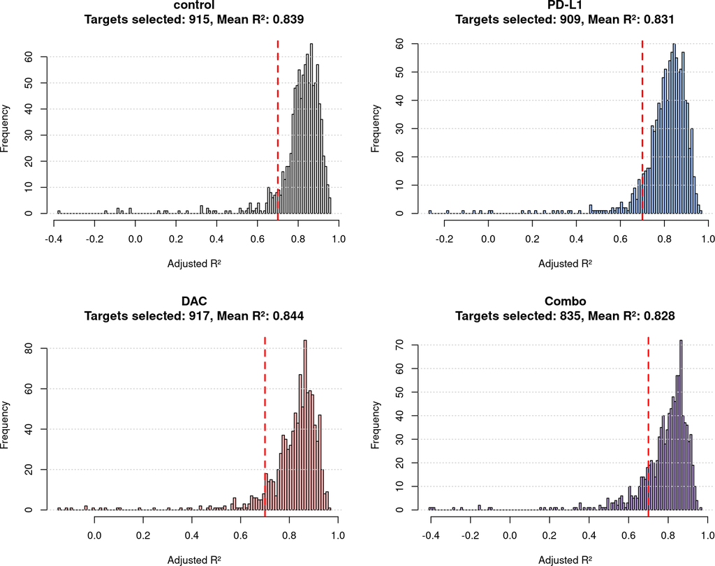

```r
# For manual loading you can extract the adjusted R2 values from the weights pickle file.
out <- read_pickle(weights_file)
adjusted_r_squared <- out$adjusted_r_squared
plot_r2_distribution(adjusted_r_squared, simic2_bis, grid=c(2,2), width= 16,save =TRUE, out_dir = plot_dir)
```

Here we can see that the distribution of adjusted R2 values across all targets. Most of them are over 0.7, indicating that the model explains a significant portion of the variance in the target gene expression. However, there are also some targets with low or negative adjusted R2 values, suggesting that the model does not fit well for those targets. This could be due to various reasons such as noise in the data, missing regulatory interactions, or complex regulatory mechanisms that are not captured by the model. For these targets with low adjusted R2, we suggest to filter them out before plotting. We select a threshold of `0.7` as it was the same used to calculate the activity scores during the SimiC pipeline. You can change this threshold as needed, but you shoudl re-run the SimiCPipeline auc calculation with the same threshold to be consistent.

```r
unselected_targets <- list()
selected_targets <- list()
lab_keys <- names(simic@label_names)
for (lab in lab_keys){
    # Save selected for plotting
    selected_targets[[lab]] <- simic@target_ids[which(adjusted_r_squared[[lab]] >= 0.7)]
    # Save unselected for reporting
    label <- simic@label_names[[lab]]
    unselected_targets[[label]] <- simic@target_ids[which(adjusted_r_squared[[lab]] < 0.7)]
}
print("Number of unselected targets per label:")
## [1] "Number of unselected targets per label:"
```

```r
print(sapply(unselected_targets, length))
## control   PD-L1     DAC   Combo
##      85      91      83     165
```

## 4.2 TF Weight barplots

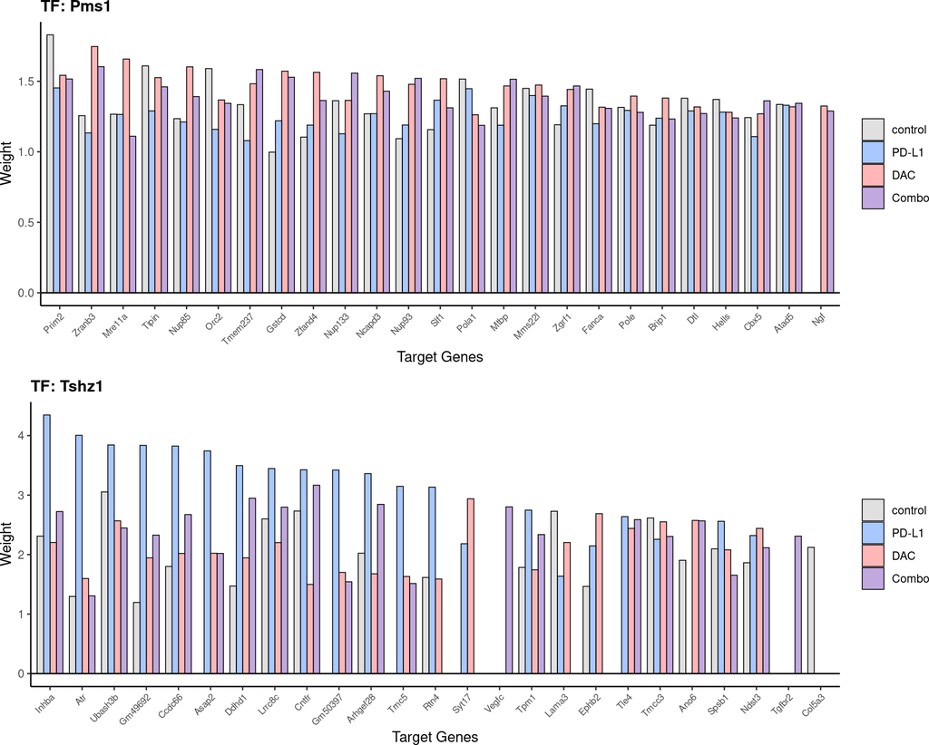

```r
 plot_tf_weights(simic,
                tf_names        = simic@tf_ids[1:4],
                top_n           = 25,
                allowed_targets = selected_targets,
                grid            = c(4,1),
                save            = TRUE,
                out_dir = plot_dir,
                filename = "TF_weights_barplot.pdf"
                )
## Plotting 4 TF weight barplot(s)...
## Saved weight barplots to: /home/workdir/SimiCviz/vignettes/SimiCviz_output/plots/TF_weights_barplot.pdf
```

## 4.3 Target Weight barplots

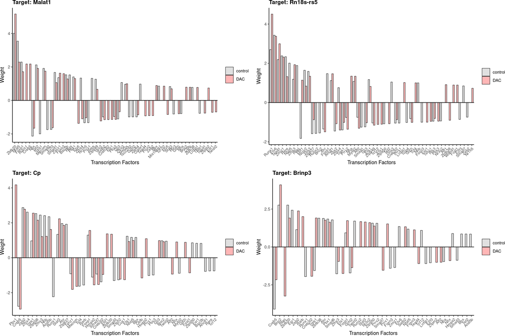

```r
plot_target_weights(simic,
                target_names = simic@target_ids[1:4],
                labels   = c("control","DAC"),
                save = TRUE,
                width= 18, # Adjust width and height as needed for grid layout
                height = 10,
                grid     = c(1, 2),
                out_dir = plot_dir,
                filename = "Target_weights_barplot.pdf")
## Plotting 4 target weight barplot(s)...
## Saved weight barplots to: /home/workdir/SimiCviz/vignettes/SimiCviz_output/plots/Target_weights_barplot.pdf
```

If you want to plot all TFs and Targets bar plots leave the `tf_names` and `target_names` arguments respectivelly blank.

```r
plot_tf_weights(simic,
                save = TRUE,
                width= 18, height = 10,
                grid     = c(3, 2),
                out_dir = plot_dir,
                filename = "All_tf_weights_barplot.pdf")
plot_target_weights(simic,
                save = TRUE,
                width= 18, height = 10,
                grid     = c(3, 2),
                out_dir = plot_dir,
                filename = "All_target_weights_barplot.pdf")
```

## 4.4 Network visualization

```r
plot_network(simic, top_n = 4)
```

# 5 AUC

## 5.1 Density distributions

Plot per-TF activity score density curves across phenotype labels.

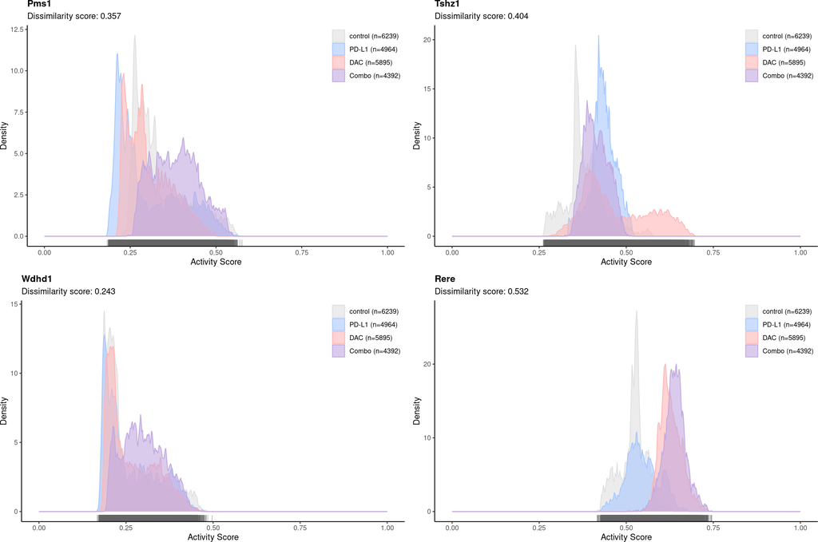

```r
# Plot top 4 TFs density distributions
plot_auc_distributions(simic,
                       tf_names = simic@tf_ids[1:4],
                       fill = TRUE,
                       alpha = .6,
                       bw_adjust = 1/8,
                       rug = TRUE,
                       save = TRUE,
                       out_dir = plot_dir,
                       filename = "AUC_distributions.pdf",
                       grid = c(2, 2))
```

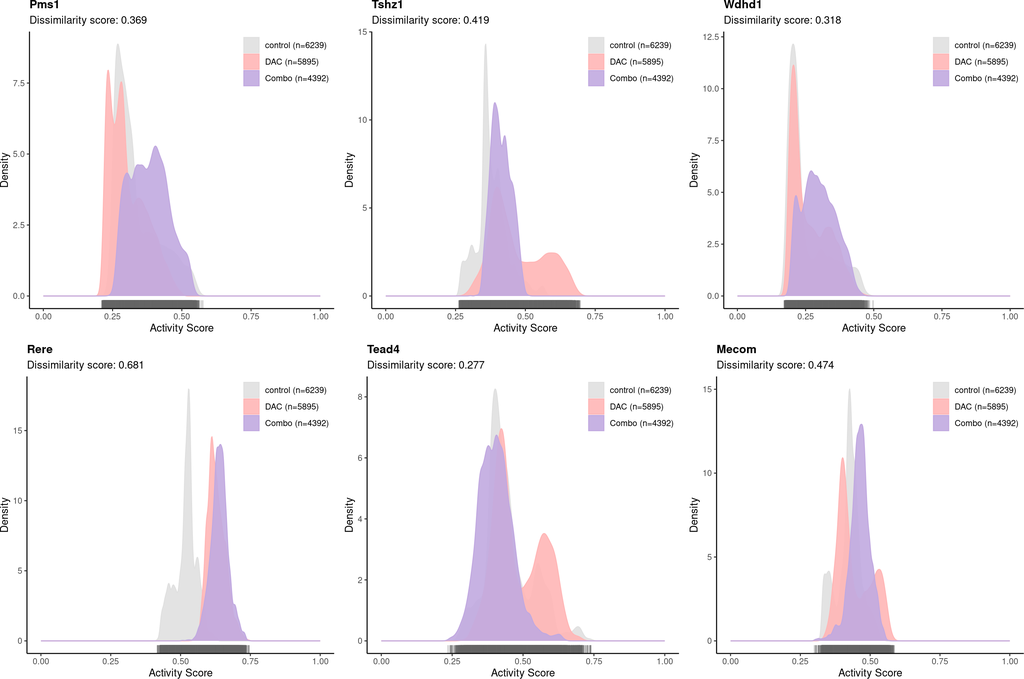

```r
# Plot top 6 TFs density distributions
plot_auc_distributions(simic,
                       labels = c(0,2,3),
                       tf_names = simic@tf_ids[1:6],
                       fill = TRUE,
                       alpha = 0.9,
                       bw_adjust = 0.8,
                       rug = TRUE,
                       out_dir = plot_dir,
                       filename="AUC_distributions_filled.pdf",
                       save = TRUE,
                       grid = c(2, 3))
```

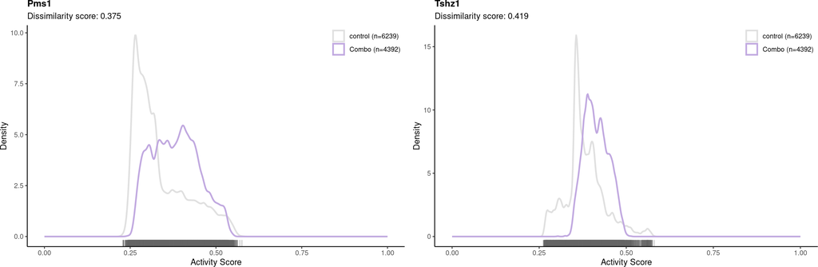

```r
# Plot top 4 TFs density distributions
plot_auc_distributions(simic,
                       labels = c(0,3),
                       tf_names = simic@tf_ids[1:2],
                       fill = FALSE,
                       alpha = 0.9,
                       bw_adjust = 0.5,
                       rug = TRUE,
                       out_dir = plot_dir,
                       filename="AUC_distributions_notfilled_multipage.pdf",
                       save = TRUE,
                       grid = c(1,2))
## Saved AUC distributions to: /home/workdir/SimiCviz/vignettes/SimiCviz_output/plots/AUC_distributions_notfilled_multipage.pdf
```

## 5.2 Cumulative distributions (ECDF)

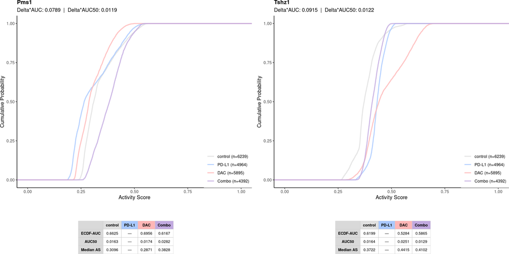

```r
plot_auc_cumulative(simic,
                    tf_names = simic@tf_ids[1:2],
                    rug = FALSE,
                    grid = c(2, 2),
                    save = TRUE,
                    include_table = TRUE,
                    width = 12, height = NULL,
                    out_dir = plot_dir)
```

# 6 Additional functions

You can convert the activity scores file into a data.frame of cells x TFs with the following function:

```r
auc_file <- system.file("extdata", file.path("outputSimic/matrices/example1"
                        ,"example1_L1_0.01_L2_0.001_wAUC_matrices_filtered_BIC.pickle"),
                            package = "SimiCviz")
auc_pkl <- read_auc_pickle(auc_file)

cell_labels_path <- system.file("extdata",file.path("inputFiles","treatment_annotation.csv"), package = "SimiCviz")
cell_labels = load_cell_labels(cell_labels_path)
auc_df <- auc_list_to_df(auc_pkl, cell_labels_df = cell_labels )
head(auc_df[,1:5])

save_collected_auc(auc_df, file = "./collected_auc.csv", overwrite = FALSE)
```

## 6.1 ECDF-AUC metrics table

```r
ecdf_metrics <- calculate_ecdf_auc(simic, tf_names = simic@tf_ids[1:6])
head(ecdf_metrics)
```

## 6.2 Summary statistics (boxplot, violin, mean bar, high-activity count)

```r
plot_auc_summary_statistics(simic)
```

## 6.3 AUC Heatmap (mean activity per TF × phenotype)

```r
plot_auc_heatmap(simic, top_n = 20)
```

If AUC data is condition-specific, you can use a heatmap:

```r
plot_auc_heatmap(simic)
```

# 7 Exporting results

```r
# getwd()
# out_dir <- "/home/workdir/SimiCviz/SimiCviz_output"
# dir.create(file.path(out_dir))
# export_SimiCviz_all(simic, out_dir = out_dir, prefix = "SimiC_example")
```

This will create:

- `data/weights`, `data/auc`
- `plots/network`, `plots/auc`

under `SimiCviz_output/`.